# Control de versiones con git y GitHub

## Cree un repositorio remoto en GitHub

Empecemos creando un repositorio en GitHub, luego editaremos algunos archivos.

[figure not shown]

Captura de pantalla de la creación de un repositorio nuevo en GitHub.

¡Usted acaba de crear su primer repositorio! Este repositorio fue creado con un par de archivos que GitHub hace por usted, son los archivos README.md, LICENSE y .gitignore.

[figure not shown]

Para hacer cambios menores a archivos de texto se puede utilizar la interfase web de GitHub. Navegue al archivo `README.md` en el listado de archivos y habilite la edición haciendo clic en el icono del *lápiz*. Este es un archivo normal con el formado Markdown, ahora se puede editar, agregando o removiendo texto. Cuando haya terminado, incluya un mensaje de commit y luego haga clic en el botón `Commit changes`.

[figure not shown]

Captura de pantalla con la interfase web de GitHub para la edición de documentos de texto.

[figure not shown]

Captura de pantalla con la interfase web de GitHub para la confirmar de los cambios realizados al documento de texto (commit changes).

Felicitaciones, ahora usted acaba de confirmar (commit) los cambios, ahora es el autor de la primera versión de este archivo. Si navega de regreso a la página del repositorio GitHub, puede ver la lista de los cambios confirmados (commits) ahí, así como la visualización del documento generado a partir del archivo README.md.

[figure not shown]

Captura de pantalla con la interfase web los cambios corfimados (commits) y de la visualización de la página README.md.

En la siguiente sección vamos a usar el URL de GitHub del repositorio que acaba de crear y lo usaremos plara clonarlo (`clone`) a un repositorio en nuestra máquina local y así editar los archivos con **RStudio**. Para eso, primero tenemos que copiar el URL de GitHub, que representa la dirección del repositorio:

[figure not shown]

Captura de pantalla para clonar un repositorio GitHub.

## Trabajando localmente con Git en RStudio

RStudio incluye soporte para Git como sistema de control de versiones, pero esto **sólo** ocurre si estamos trabajando en un *Proyecto de RStudio* (RStudio project folder). En esta sección vamos a clonar el repositorio que se creó en GitHub y lo vamos a dejar un repositorio local de un proyecto de RStudio.

Esto es lo que vamos a hacer:

1. Crear un proyecto nuevo.
2. Inspeccionar el panel Git y el historial de versiones.
3. Confirmar una modificación (commit) al archivo README.md.
4. Commit las modificaciones que hicieron en RStudio.
5. Inspeccionar el historial de versiones.
6. Crear y commit un archivo Rmd.
7. Enviar (*Push*) estos cambios a GitHub.
8. Ver el historial de cambios en GitHub.

### Crear nuevo Proyecto (Create a New Project)

[figure not shown]

Captura de pantalla para la creasción de un proyecto de RStudio clonando un repositorio remoto.

Un vez que haga clic en `Create Project` (crear proyecto), una nueva página de RStudio se abrirá con todos los archivos copiados localmente desde el repositorio remoto. Dependiendo de como esté configurada la versión de RStudio, la posición y tamaño de los paneles puede cambiar, pero generalmente todos van a estar presentes, incluyendo los paneles *Git* y el listado de archivos (*Files*) que fueron creados en el repositorio remoto.

[figure not shown]

Captura de pantalla de la interfase del projecto de RStudio con el clon local de repositorio.

### Inspeccionar el historial (history)

A continuación vamos a hacer clic en el botón *History* (historial, es el reloj que aparece en la primera fila al interior del panel ed Git), esto despliega una ventana con el registro de los cambios que se han realizado y, en este caso, deben ser idénticos a lo que usted vio en GitHub. Al hacer clic en cada fila del historial, podrá ir viendo exactamente que fue agregado y cambiado en cada uno de los commits en este repositorio.

[figure not shown]

Historial de los cambios realizados en el repositorio local.

### Confirme cambios haciendo clic en *commit* al archivo README.md (Commit a README.md change)

Ahora hagamos algunos cambios al archivo README.md en RStudio. Agregue una sección nueva con un block de *markdown* como este:

```
## Git desde RStudio

Desde la interfase de RStudio, es posible hacer las mismas acciones con el sistema de versiones que se hicieron en  GitHub
y mucho más. Además en RStudio se tienen las ventajas propias de programar en un IDE con completación de comandos y otras
características que hacen nuestro trabajo más fácil.

- Agregar archivos al control de versiones
- Ccommit cambios
- Push commits a GitHub
```

Una vez que los haya guardado, podrá ver en forma inmediata el archivo *README.md* en el panel Git (fig. @ref(fig:rstudioPanelStatus)), marcado con una **M** de modificación. Ahora usted puede seleccionar este archivo en el panel de Git y hacer clic en *Diff* para ver los cambios (comparando las diferencias) que guardó (note que estos cambios no se han confirmado (*commit*) aun a su repositorio local).

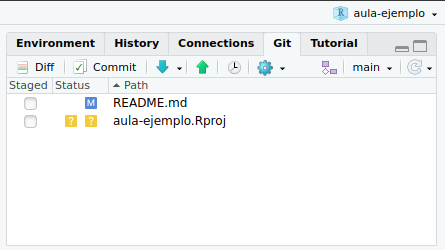

Panel de estado de los cambios en los archivos.

En la figura @ref(fig:rstudioDiferencias) se muestra como se ven los cambios comparados con el archivo original. La líneas nuevas se destacan en color verde y en rojo las que fueron eliminadas.

[figure not shown]

Ventana que presenta las diferencias entre la versión almacenada en el repositorio y los últimos cambios realizados.

### Commit los cambios hechos en Rstudio

Para confirmar los cambios que se acaban de hacer en el archivo README.md, selecciones la caja de selección *Staged* a lado del nombre del archivo, este le dice a Git cuales son los cambios que quiere sean incluidos en el commit, escriba un mensaje describiendo que cambios se hicieron y por qué y finalmente haga clic en boton *Commit* (fig. @ref(fig:rstudioCommit1)).

[figure not shown]

Captura de pantalla con un mensaje describiendo la confirmación (commit) que se realizará.

Lo que se traduce a:

```
_Su rama esta más avanzadada que el
‘maestro/origen’ por una confirmación
```

Esto significa que hemos commit **1** cambio en el repositorio local, pero que este no se está en el repositorio de origen (`origin`), no se ha hecho push, donde origen es el nombre que se usa típicamente para el repositorio en GitHub. Entonces, confirmemos los cambios pendientes, para esto seleccione la caja *staged* y luego escriba el mensaje describiendo el commit (fig. @ref(fig:rstudioCommit2)).

[figure not shown]

Captura de pantalla con los archivos a confirmar sus cambios y el texto descriptivo de la confirmación.

Cuando haya terminado no habrán mas cambios pendientes en el panel *Git* y el repositorio estará completamente limpio.

### Inspeccionando el historial

Fíjese que ahora el mensaje dice:

[output not shown]

[output not shown]

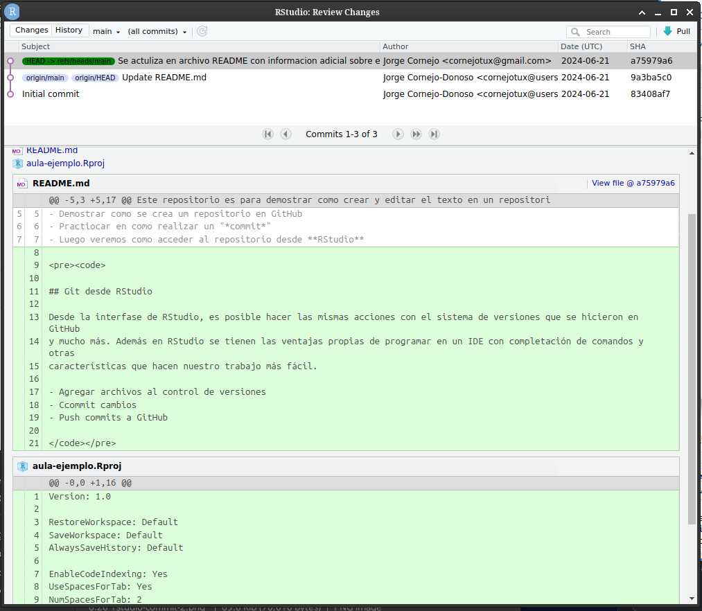

### Enviar (Push) cambios a GitHub

[figure not shown]

Ahora puede ver que las etiquetas del repositorio local (`HEAD`) y del remoto (`origin/HEAD`) están apuntando a la misma versión en el historial. De esta forma, si miramos el historial de los commits en GitHub serán iguales a los que tenemos en forma local.

[figure not shown]

Captura de pantalla con el historial de cambios en github.

## Sobre (buenos) mensajes de confirmación (commit)

Si bien muchos de los cambios que aquí se hicieron son simples y se explican por si mismos, para cambios más complejos, es mejor entregar un mensaje completo y auto-contenido. La convención, sin embargo, es tratar de usar mensajes cortos, con una sentencia breve, seguido de una explicación más detallada y racional para el cambio. Esto permite que el nivel de detalles sea legible en el registro de las versiones (version log). No puedo contar el número de veces que he visto los registro d e commits de hace 2, 3 o 10 años y agradecido el nivel de diligencia de los colaboradores que se tomaron el tiempo de describir el trabajo que se realizó.

## Flujos de trabajo colaborativos y libres de conflictos (relacionados con Git)

Hasta ahora nos hemos enfocado al uso de Git y GitHub para el uso personal, como ya se demostró esto es extremadamente útil. Sin embargo donde git y GitHua brilla es cuando se comparte un repositorio GitHub con colaboradores, de esta forma se pede trabajar en un código, análisis y modelos en forma colaborativa. Cuando se trabaja de esta manera con otros investigadores, es muy importante poner atención al estado del repositorio remoto para evitar potenciales conflictos al combinar el trabajo. Un *merge conflict* ocurre cuando dos colaboradores hacen 2 commits en forma separada donde se ha(n) cambiado(s) la(s) misma(s) línea(s) de código de un archivo. Cuando esto ocurre, git no puede combinar los cambios en forma automática y arroja un error preguntando como resolver el conflicto. Esto no es grave, no es necesario tenerle miedo a los *merge conflicts* ya que son muy fáciles resolver y aquí hay algunas [guías](https://help.github.com/articles/resolving-a-merge-conflict-using-the-command-line/) [geniales](https://stackoverflow.com/questions/161813/how-to-resolve-merge-conflicts-in-git). de como hacerlo (por ahora sólo en inglés).

Dicho esto, es siempre mejor evadir este tipo de conflictos, lo que se pueden minimizar siguiendo las siguientes sugerencias:

- Asegúrese de traer (*pull down*) todos los cambios antes de confirmarlos (commit).
  - Asegurese que tiene los cambios más recientes.
  - Pero puede ser que necesite arreglar su código si ocurren conflictos.
- Coordínese con con sus colaboradores con quien va a trabajar.
  - Usted **tiene** que comunicarse para colaborar.

## Tópicos avanzados

Hay mucho que no hemos visto en este tutorial. Existen tutoriales muy completos que cubren tópicos mas avanzados. Algunos de estos temas son:

- Usando git en la linea de comándos.
- Resolviendo conflictos.
- *Branching* y *merging*.
- *Pull requests* versus contribuciones directas por colaboradores.
- Usando *.gitignore* para proteger datos sensitivos.
- *GitHub Issues* y por que son útiles.
- y más, mucho más.
- [Try Git](https://try.github.io) es un tutorial interactivo muy bueno y completo.
- Software Carpentry [Version Control with Git](http://swcarpentry.github.io/git-novice/)
- Codecademy [Learn Git](https://www.codecademy.com/learn/learn-git) (some paid)